# Weekly residence model

Quasibinomial

Mike O’Brien

9/1/2021

```r
library(data.table); library(mgcv); library(itsadug)
basswl <- fread('bassweek.csv')
basswl[, Origin := factor(Origin)]
basswl[, transmitter := factor(transmitter)]

# Need to label where each fish's time series starts for the AR1 model
basswl[, ar_start := fifelse(time == 1, T, F)]
basswl[, trials := 7]
```

The following fits models with autocorrelation parameters ($\rho$) from 0 to 0.999 and retains the AIC returned.

Note the use of `scale = -1`. This this tricks `mgcv::bam` into fitting a scale parameter, meaning that we are technically fitting a quasibinomial model. If you use the `quasibinomial` function directly, AIC is not reported since it technically is a quasilikelihood that shouldn’t be compared to other quasilikelihoods. The R creators are purists and don’t want you to see that the likelihood is still calculated behind the curtain and that AIC can still be pulled out.

I also increased k in `s(WE)` to 28 since the cyclic spline seems to take 2 degrees of freedom. Using 28 rather than 27 gives us the max of 26 knots that we were looking for.

```r
search <- sapply(seq(0, 0.999, 0.001), function(x){
  AIC(mgcv::bam(cbind(freq, trials) ~
                  Origin +
                  s(SST, bs='tp', k = 11) +
                  s(WE, bs='cc', k = 28) +
                  s(CHLA, bs= 'tp', k = 6) +
                  s(transmitter, bs = 're'),
                rho = x, AR.start = ar_start,
                family = binomial, discrete = T,

                scale = -1,

                data=basswl))
})
```

It comes out that $\rho$ = 0.865 is the optimal value according to AIC, so if you want to run it yourself, I’d change the sequence range to something like `seq(0.85, 0.87, 0.001)` to make it go faster.

```r
search <- sapply(seq(0.86, 0.87, 0.001), function(x){
  AIC(mgcv::bam(cbind(freq, trials) ~
                  Origin +
                  s(SST, bs='tp', k = 11) +
                  s(WE, bs='cc', k = 28) +
                  s(CHLA, bs= 'tp', k = 6) +
                  s(transmitter, bs = 're'),
                rho = x, AR.start = ar_start,
                family = binomial, discrete = T,

                scale = -1,

                data=basswl))
})
```

Return the best value of $\rho$ (note that I did change the sequence range once I had an idea of where $\rho$ was to make it run faster):

```r
seq(0.86, 0.87, 0.001)[which.min(search)]
```

```
## [1] 0.865
```

And now, run the model:

```r
model <- bam(cbind(freq, trials) ~
               Origin +
               s(SST, bs='tp', k = 11) +
               s(WE, bs='cc', k = 28) +
               s(CHLA, bs= 'tp', k = 6) +
               s(transmitter, bs = 're'),
             rho = 0.865, AR.start = basswl$ar_start,
             family = binomial, discrete = T,
             scale = -1, data=basswl)

summary(model)
```

```
##
## Family: binomial
## Link function: logit
##
## Formula:
## cbind(freq, trials) ~ Origin + s(SST, bs = "tp", k = 11) + s(WE,
##     bs = "cc", k = 28) + s(CHLA, bs = "tp", k = 6) + s(transmitter,
##     bs = "re")
##
## Parametric coefficients:
##                          Estimate Std. Error t value Pr(>|t|)
## (Intercept)              -4.54052    0.11650 -38.973   <2e-16 ***
## OriginHudson River, NY    0.29909    0.13170   2.271   0.0231 *
## OriginKennebec River, ME  0.17293    0.25572   0.676   0.4989
## OriginMassachusetts       0.17392    0.10910   1.594   0.1109
## OriginPotomac River, MD   0.08197    0.22944   0.357   0.7209
## ---
## Signif. codes:  0 '***' 0.001 '**' 0.01 '*' 0.05 '.' 0.1 ' ' 1
##
## Approximate significance of smooth terms:
##                    edf  Ref.df       F p-value
## s(SST)           8.406   9.362  45.964  <2e-16 ***
## s(WE)           23.906  26.000  90.127  <2e-16 ***
## s(CHLA)          1.002   1.004 301.685  <2e-16 ***
## s(transmitter) 223.077 310.000   2.984  <2e-16 ***
## ---
## Signif. codes:  0 '***' 0.001 '**' 0.01 '*' 0.05 '.' 0.1 ' ' 1
##
## R-sq.(adj) =  -0.993   Deviance explained = -48.6%
## fREML =  15037  Scale est. = 0.56127   n = 33705
```

Note that “Scale est.” is much less than 1. This indicates that that the data are, indeed, underdispersed. If you run this using the binomial family without `scale = -1`, you will see that “Scale est.” is fixed at 1.

The adjusted R<sup>2</sup> and deviance explained are obviously pretty funky, but I think I can calculate those by hand later.

CHLA is basically linear, so re-running without a smooth for that term:

```r
model <- bam(cbind(freq, trials) ~
               Origin +
               s(SST, bs='tp', k = 11) +
               s(WE, bs='cc', k = 28) +
               CHLA +
               s(transmitter, bs = 're'),
             rho = 0.865, AR.start = basswl$ar_start,
             family = binomial, discrete = T,
             scale = -1, data=basswl)

summary(model)
```

```
##
## Family: binomial
## Link function: logit
##
## Formula:
## cbind(freq, trials) ~ Origin + s(SST, bs = "tp", k = 11) + s(WE,
##     bs = "cc", k = 28) + CHLA + s(transmitter, bs = "re")
##
## Parametric coefficients:
##                          Estimate Std. Error t value Pr(>|t|)
## (Intercept)              -4.32981    0.11664 -37.122   <2e-16 ***
## OriginHudson River, NY    0.29909    0.13170   2.271   0.0231 *
## OriginKennebec River, ME  0.17293    0.25572   0.676   0.4989
## OriginMassachusetts       0.17392    0.10910   1.594   0.1109
## OriginPotomac River, MD   0.08197    0.22944   0.357   0.7209
## CHLA                     -0.22148    0.01272 -17.408   <2e-16 ***
## ---
## Signif. codes:  0 '***' 0.001 '**' 0.01 '*' 0.05 '.' 0.1 ' ' 1
##
## Approximate significance of smooth terms:
##                    edf  Ref.df      F p-value
## s(SST)           8.406   9.362 45.967  <2e-16 ***
## s(WE)           23.906  26.000 90.129  <2e-16 ***
## s(transmitter) 223.077 310.000  2.978  <2e-16 ***
## ---
## Signif. codes:  0 '***' 0.001 '**' 0.01 '*' 0.05 '.' 0.1 ' ' 1
##
## R-sq.(adj) =  -0.993   Deviance explained = -48.6%
## fREML =  15036  Scale est. = 0.56127   n = 33705
```

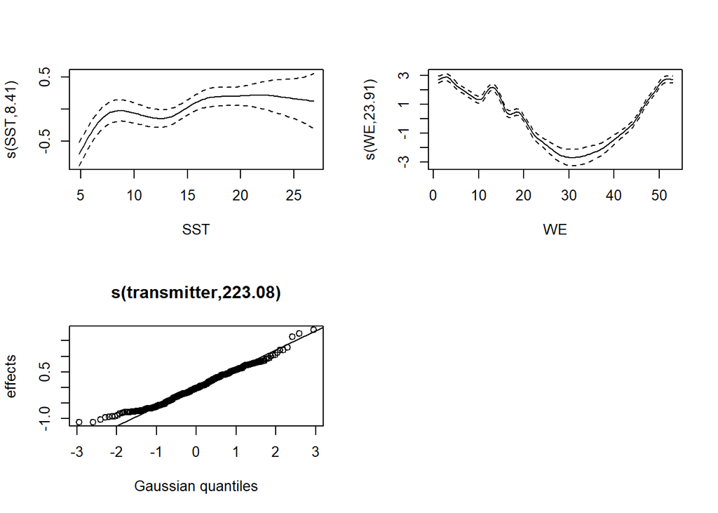

```r
plot(model, scale = 0, pages = 1)
```

You can see from the random subset of fish below that there’s still some autocorrelation, but we’ve done the best we probably can!

```r
acf_resid(model, split_pred = 'AR.start', n = 6)
```

```
## Quantiles to be plotted:
##         0%        20%        40%        60%        80%       100%
## -0.7527925 -0.4552767 -0.4030913 -0.3247017 -0.1632716  0.3270733
```

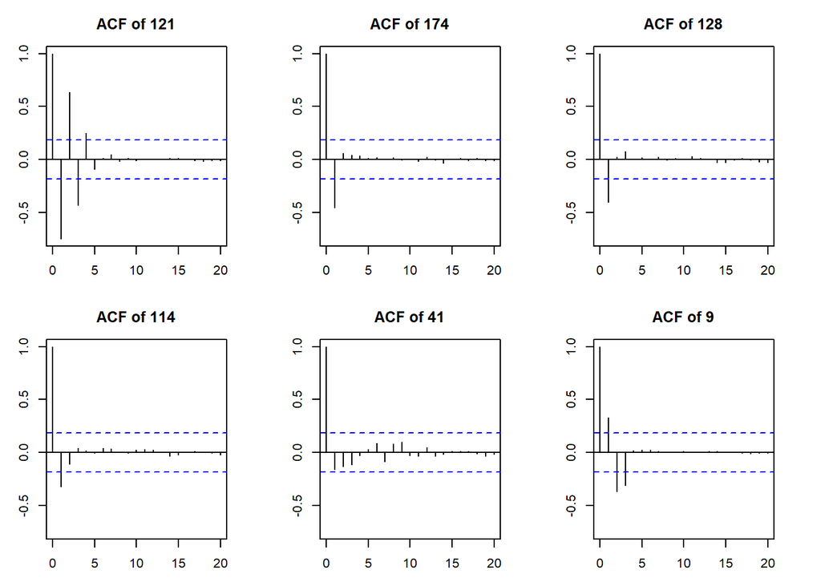

Looks like the Delaware and Hudson may be different…

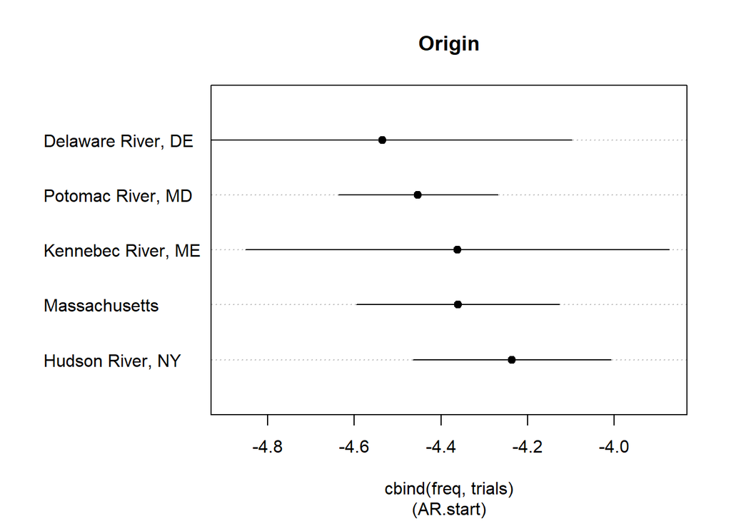

```r
plot_parametric(model,
                pred = list(Origin = levels(basswl$Origin)),
                parametricOnly = T)
```

…and they seem to be!

```r
wald_gam(model,
         comp = list(Origin = levels(basswl$Origin)),
         print.output = T)
```

```
##
## Wald test
## -----
## model: cbind(freq, trials) ~ Origin + s(SST, bs = "tp", k = 11) + s(WE,
##     bs = "cc", k = 28) + CHLA + s(transmitter, bs = "re")
##
## Parametric effects:
##              (Intercept)   OriginHudson River, NY OriginKennebec River, ME
##              -4.32980744               0.29908945               0.17293205
##      OriginMassachusetts  OriginPotomac River, MD                     CHLA
##               0.17392349               0.08196991              -0.22147519
##
## Null hypothesis =  0
##
## Comparing Hudson River, NY with Potomac River, MD:
##  X2(1.000) = 0.884, p = 0.347
##
##  Comparing Hudson River, NY with Kennebec River, ME:
##  X2(1.000) = 0.241, p = 0.624
##
##  Comparing Hudson River, NY with Massachusetts:
##  X2(1.000) = 1.246, p = 0.264
##
##  Comparing Massachusetts with Potomac River, MD:
##  X2(1.000) = 0.177, p = 0.674
##
##  Comparing Kennebec River, ME with Potomac River, MD:
##  X2(1.000) = 0.082, p = 0.775
##
##  Comparing Kennebec River, ME with Massachusetts:
##  X2(1.000) = 0.000, p = 0.997
##
##  Comparing Delaware River, DE with Potomac River, MD:
##  X2(1.000) = 0.128, p = 0.721
##
##  Comparing Delaware River, DE with Kennebec River, ME:
##  X2(1.000) = 0.457, p = 0.499
##
##  Comparing Delaware River, DE with Massachusetts:
##  X2(1.000) = 2.541, p = 0.111
##
##  Comparing Delaware River, DE with Hudson River, NY:
##  X2(1.000) = 5.158, p = 0.023 *
```